# The Sampling Distribution of the Mean

Alyssah

June 10, 2026

## 1. The Population

We start with a **skewed population** — drawn from an exponential distribution. This is intentional: an exponential distribution looks nothing like a normal curve. Using a non-normal population lets us clearly observe the Central Limit Theorem at work later on.

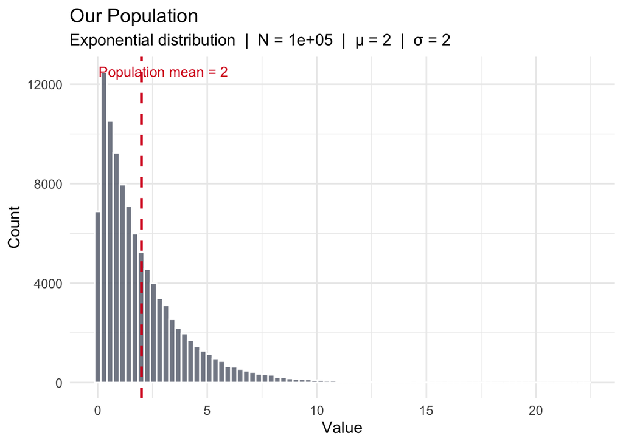

```r
set.seed(42)

POPULATION_SIZE <- 100000
population <- rexp(POPULATION_SIZE, rate = 0.5)

pop_mean <- mean(population)
pop_sd   <- sd(population)

ggplot(data.frame(x = population), aes(x = x)) +
  geom_histogram(bins = 80, fill = "#6B7280", color = "white", alpha = 0.85) +
  geom_vline(xintercept = pop_mean, color = "#d7191c", linewidth = 1, linetype = "dashed") +
  annotate("text",
           x = pop_mean + 1, y = Inf, vjust = 2,
           label = paste0("Population mean = ", round(pop_mean, 2)),
           color = "#d7191c", size = 4) +
  labs(
    title = "Our Population",
    subtitle = paste0("Exponential distribution  |  N = ", format(POPULATION_SIZE, big.mark = ","),
                      "  |  μ = ", round(pop_mean, 2),
                      "  |  σ = ", round(pop_sd, 2)),
    x = "Value", y = "Count"
  ) +
  theme_minimal(base_size = 13)
```

**What you should notice:** The population is heavily right-skewed. Most values are near zero but a long tail stretches to the right. This is a realistic shape — income distributions, wait times, and many natural phenomena look like this.

## 2. What Is a Sampling Distribution?

If you draw a random sample of size *n* from this population and compute the sample mean, you get one number. Do that 1,000 times and you have 1,000 sample means. The distribution of those means is called the **sampling distribution of the mean**.

The key question: *what does that distribution look like, and how does sample size change it?*

We’ll answer this by running the experiment at three sample sizes:

| Label | Sample size *n* |
| --- | --- |
| Small | 5 |
| Medium | 30 |
| Large | 100 |

## 3. Simulating 1,000 Samples

```r
N_SAMPLES   <- 1000
small_n     <- 5
medium_n    <- 30
large_n     <- 100

sample_means <- function(pop, n, reps) {
  replicate(reps, mean(sample(pop, size = n, replace = FALSE)))
}

means_small  <- sample_means(population, small_n,  N_SAMPLES)
means_medium <- sample_means(population, medium_n, N_SAMPLES)
means_large  <- sample_means(population, large_n,  N_SAMPLES)

results <- bind_rows(
  data.frame(sample_mean = means_small,  size = paste0("Small (n = ",  small_n,  ")")),
  data.frame(sample_mean = means_medium, size = paste0("Medium (n = ", medium_n, ")")),
  data.frame(sample_mean = means_large,  size = paste0("Large (n = ",  large_n,  ")"))
) %>%
  mutate(size = factor(size, levels = c(
    paste0("Small (n = ",  small_n,  ")"),
    paste0("Medium (n = ", medium_n, ")"),
    paste0("Large (n = ",  large_n,  ")")
  )))
```

We now have a data frame with 3,000 rows: 1,000 sample means for each of the three sample sizes.

## 4. Visualising the Three Sampling Distributions

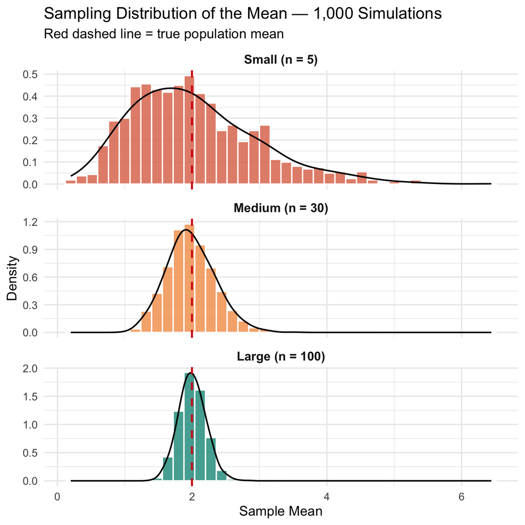

```r
panel_colors <- setNames(
  c("#E07A5F", "#F4A261", "#2A9D8F"),
  c(paste0("Small (n = ",  small_n,  ")"),
    paste0("Medium (n = ", medium_n, ")"),
    paste0("Large (n = ",  large_n,  ")"))
)

ggplot(results, aes(x = sample_mean, fill = size)) +
  geom_histogram(aes(y = after_stat(density)),
                 bins = 40, color = "white", alpha = 0.85) +
  stat_density(geom = "line", color = "black", linewidth = 0.7, adjust = 1.5) +
  geom_vline(xintercept = pop_mean,
             color = "#d7191c", linetype = "dashed", linewidth = 0.9) +
  facet_wrap(~size, ncol = 1, scales = "free_y") +
  scale_fill_manual(values = panel_colors, guide = "none") +
  labs(
    title = "Sampling Distribution of the Mean — 1,000 Simulations",
    subtitle = "Red dashed line = true population mean",
    x = "Sample Mean", y = "Density"
  ) +
  theme_minimal(base_size = 13) +
  theme(strip.text = element_text(face = "bold", size = 12))
```

## 5. Overlaid Comparison

Placing all three distributions on one plot makes the shape and spread differences unmistakable.

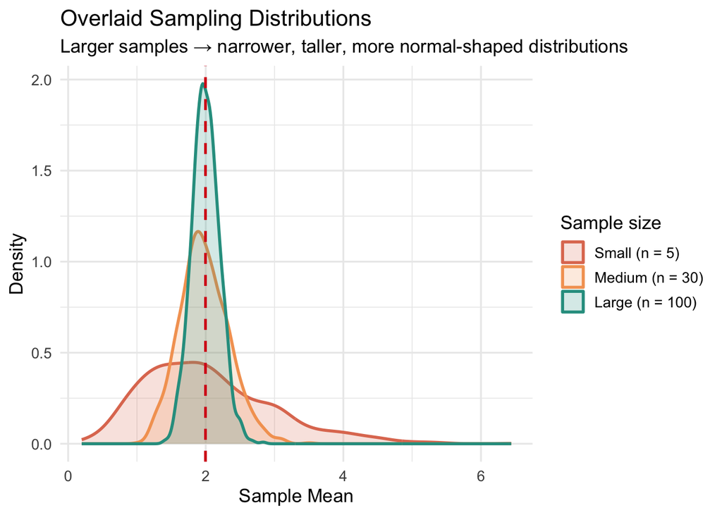

```r
ggplot(results, aes(x = sample_mean, color = size, fill = size)) +
  geom_density(alpha = 0.20, linewidth = 1) +
  geom_vline(xintercept = pop_mean,
             color = "#d7191c", linetype = "dashed", linewidth = 0.9) +
  scale_color_manual(values = panel_colors) +
  scale_fill_manual(values = panel_colors) +
  labs(
    title = "Overlaid Sampling Distributions",
    subtitle = "Larger samples → narrower, taller, more normal-shaped distributions",
    x = "Sample Mean", y = "Density",
    color = "Sample size", fill = "Sample size"
  ) +
  theme_minimal(base_size = 13)
```

**What you should notice:**

- All three distributions are **centred on the true population mean** — sampling is unbiased regardless of *n*.
- The small-sample distribution is wide and slightly skewed (it still carries echoes of the population’s shape).
- The medium and large distributions look increasingly **bell-shaped**, even though the underlying population is exponential.
- The large-sample distribution is **tightly concentrated** — large samples give much more precise estimates.

## 6. The Central Limit Theorem in Numbers

The **Central Limit Theorem (CLT)** tells us exactly what to expect. For samples of size *n* drawn from a population with mean μ and standard deviation σ:

$$\bar{X} \sim \mathcal{N}\!\left(\mu,\
\frac{\sigma}{\sqrt{n}}\right) \quad \text{as } n \to
\infty$$

The quantity σ/√n is called the **standard error of the mean (SE)**. Let’s compare the theoretical SE to what we actually observed in the simulation.

```r
summary_tbl <- results %>%
  group_by(size) %>%
  summarise(
    n          = as.integer(sub(".*= (\\d+)\\)", "\\1", as.character(size[1]))),
    observed_mean = round(mean(sample_mean), 4),
    observed_se   = round(sd(sample_mean),   4),
    .groups = "drop"
  ) %>%
  mutate(
    theoretical_se = round(pop_sd / sqrt(n), 4),
    ratio          = round(observed_se / theoretical_se, 3)
  )

knitr::kable(summary_tbl,
  col.names = c("Sample size", "n", "Observed mean", "Observed SE",
                "Theoretical SE (σ/√n)", "Ratio (obs/theory)"),
  caption   = "Comparison of observed simulation results vs. CLT predictions"
)
```

Comparison of observed simulation results vs. CLT predictions

| Sample size | n | Observed mean | Observed SE | Theoretical SE (σ/√n) | Ratio (obs/theory) |
| --- | --- | --- | --- | --- | --- |
| Small (n = 5) | 5 | 2.0312 | 0.9348 | 0.8950 | 1.044 |
| Medium (n = 30) | 30 | 1.9811 | 0.3563 | 0.3654 | 0.975 |
| Large (n = 100) | 100 | 2.0001 | 0.2009 | 0.2001 | 1.004 |

The ratio column should be very close to 1.0, confirming the CLT prediction.

## 7. How Standard Error Shrinks with Sample Size

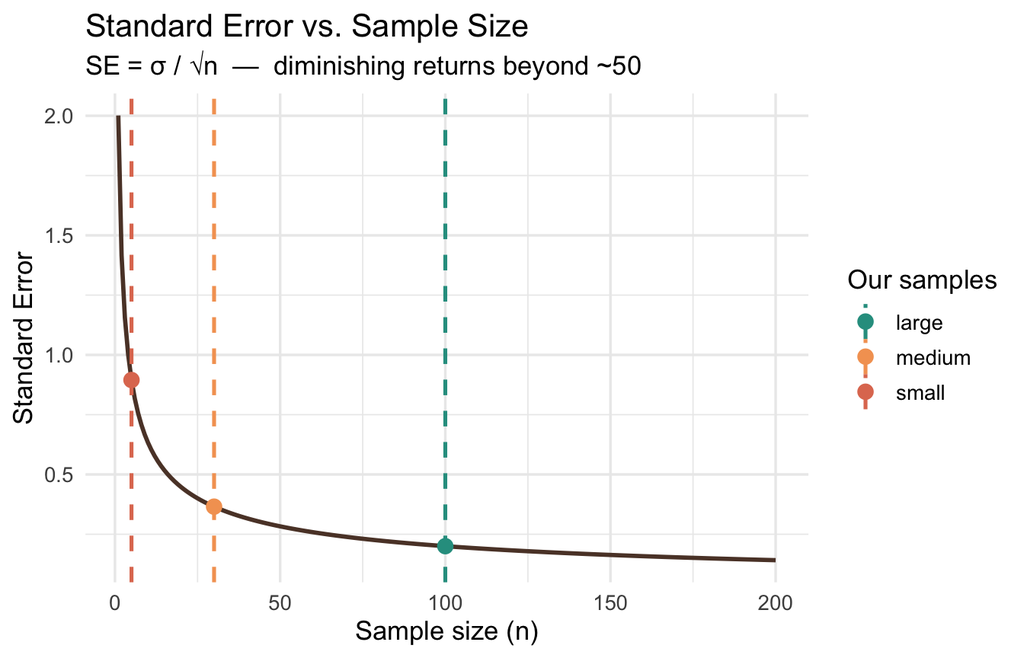

```r
ns     <- 1:200
se_df  <- data.frame(n = ns, se = pop_sd / sqrt(ns))
vlines <- data.frame(n = c(small_n, medium_n, large_n),
                     label = c("small", "medium", "large"),
                     color = c("#E07A5F", "#F4A261", "#2A9D8F"))

ggplot(se_df, aes(x = n, y = se)) +
  geom_line(linewidth = 1, color = "#5C4033") +
  geom_vline(data = vlines, aes(xintercept = n, color = label),
             linetype = "dashed", linewidth = 0.9) +
  geom_point(data = vlines, aes(x = n, y = pop_sd / sqrt(n), color = label),
             size = 3) +
  scale_color_manual(values = setNames(vlines$color, vlines$label)) +
  labs(
    title = "Standard Error vs. Sample Size",
    subtitle = "SE = σ / √n  —  diminishing returns beyond ~50",
    x = "Sample size (n)", y = "Standard Error",
    color = "Our samples"
  ) +
  theme_minimal(base_size = 13)
```

**Key insight:** Going from n = 5 to n = 30 yields a dramatic drop in SE. Going from n = 30 to n = 100 helps, but the gains are smaller. Doubling the sample size cuts SE by a factor of √2 ≈ 1.41 — not 2. This is the law of **diminishing returns in sampling**.

## 8. Summary

| Concept | What we saw |
| --- | --- |
| **Unbiasedness** | All three sampling distributions centred on the true population mean μ. |
| **Central Limit Theorem** | Even from a skewed exponential population, sample means became approximately normal as *n* grew. |
| **Standard error** | SE = σ/√n — observed SEs matched the formula closely. |
| **Diminishing returns** | Halving SE requires quadrupling *n*. |

The sampling distribution of the mean is the foundation of **confidence intervals**, **hypothesis testing**, and almost every inferential statistic you will encounter. Understanding that the sample mean is itself a random variable — with its own distribution, mean, and spread — is the key conceptual leap in statistics.